# Reproducible Pitch

1.2.2020

## Requirements

OK, you've made your shiny app, now it's time to make your pitch. You get 5 slides (inclusive of the title slide) to pitch a your app. You're going to create a web page using Slidify or Rstudio Presenter with an html5 slide deck.

Here's what you need

5 slides to pitch our idea done in Slidify or Rstudio Presenter Your presentation pushed to github or Rpubs A link to your github or Rpubs presentation pasted into the provided text box Your presentation must satisfy the following

It must be done in Slidify or Rstudio Presenter It must be 5 pages It must be hosted on github or Rpubs It must contained some embedded R code that gets run when slidifying the document

## Single Variable Scatter vs Infant Mortality (boxplot)

#### Use a scatter/boxplot to explore each parameter and its relationship with Infant Mortality

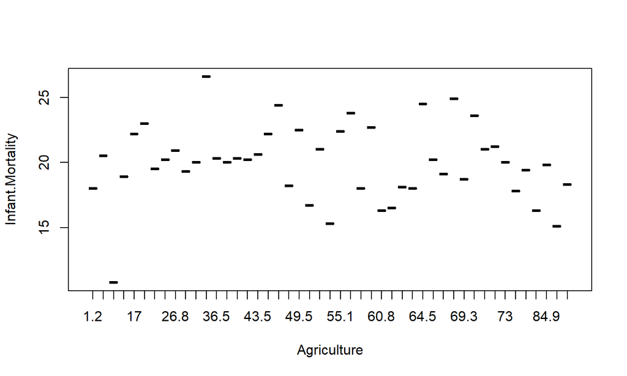

## Single Variable Regression vs Infant Mortality (linear regression)

#### Use linear regression to explore each parameter and its relationship with Infant Mortality

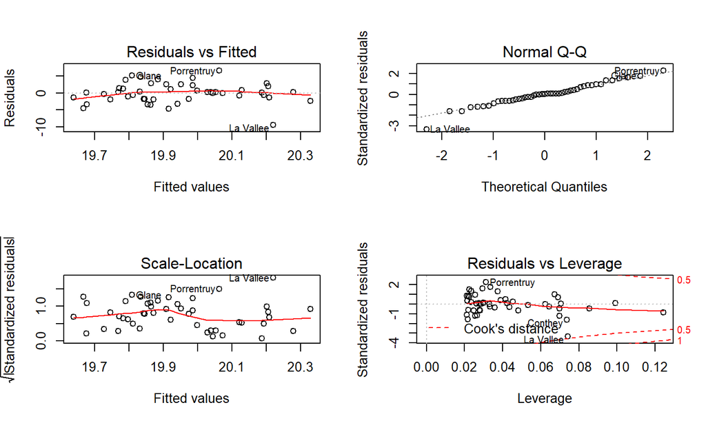

## Lasso Use Case

#### Use Lasso Regression to determine feature importance and show those features to user:

```
##          name   coefficient          abs
## 1 (Intercept) 10.0761700246 1.007617e+01
## 2   Fertility  0.1387983135 1.387983e-01
## 5   Education  0.0499692158 4.996922e-02
## 4 Examination  0.0215908881 2.159089e-02
## 3 Agriculture -0.0155216737 1.552167e-02
## 6    Catholic  0.0003018266 3.018266e-04
```

#### Use lasso regression to fit model? (perhaps not for this model!)

#### R^2 below

```
##                         s0
## Infant.Mortality 0.1987922
```